# Compute SHAP from CNN

This notebook applies SHAP (SHapley Additive exPlanations), a game-theory based explainability method, to the trained CNN. SHAP identifies which wavelengths in the spectrum are most important for predicting each atmospheric parameter. Unlike gradient methods, SHAP uses perturbation to measure feature importance by comparing predictions with and without each input feature. The results quantify exactly how much each wavelength region contributes to the model's predictions.

#### Setup

```python
import numpy as np
import os
from tensorflow.keras.models import load_model
from tensorflow.keras.models import Model
from tensorflow.keras.optimizers import Adam
from sklearn.preprocessing import StandardScaler, MinMaxScaler
import pickle as pk
import pandas as pd
import shap
import matplotlib.pyplot as plt
import seaborn as sns
from scipy.signal import find_peaks, peak_prominences

import sys
sys.path.append("../")
from src.SHAPVisualizer import plot_shap_spread
```

```
2025-09-26 14:16:36.546646: I tensorflow/core/platform/cpu_feature_guard.cc:182] This TensorFlow binary is optimized to use available CPU instructions in performance-critical operations.
To enable the following instructions: AVX2 FMA, in other operations, rebuild TensorFlow with the appropriate compiler flags.
```

SHAP requires the same preprocessing pipeline used during model training to ensure consistent input formatting. We load the full dataset and apply identical standardization transformations. This section also creates a background dataset (1000 samples) that SHAP uses as a reference distribution, and a test set (300 samples) for computing explanations.

## **1. Load and Preprocess Training Data**

```python
# Load or create reference data path
__dataset_path__ = os.getenv("TelescopeML_reference_data")
__folder__ = "training_datasets"

# DataFrame with cols grid points then spectra
__dataset_file__ = "browndwarf_R100_v4_newWL_v3.csv.bz2"
dataset = pd.read_csv(os.path.join(__dataset_path__,__folder__,__dataset_file__), compression='bz2')

# Wavelength grid of model
__wavelength_file__ = "wl.csv"
wl = pd.read_csv(os.path.join(__dataset_path__,__folder__,__wavelength_file__)).to_numpy().squeeze()
```

### **1.1 Input and Output**

```python
# Model parameters
parameters = np.array(['gravity',
             'temperature',
             'c_o_ratio',
             'metallicity'])

# Training variables
X = dataset.drop(
    columns=parameters)

# Target/Output feature variables
y = dataset[parameters]

# log transform temperature variable
y.loc[:, 'temperature'] = np.log10(y['temperature'])
```

### **1.2 Standardize**

The background dataset represents the typical distribution of spectra the model was trained on. SHAP uses this as a baseline to measure how each feature changes predictions. We randomly sample 1000 spectra for the background and 300 different spectra for testing, ensuring no overlap between the two sets. This separation prevents data leakage and ensures unbiased explanations.

```python
# Standardize input
scaler_X = StandardScaler()
X_standardized_rowwise = scaler_X.fit_transform(X.T).T
X_standardized_rowwise=X_standardized_rowwise.reshape(-1, 104, 1) # add extra dim for CNN

# Standardize output
scaler_y = StandardScaler()
y_standardized_columnwise = scaler_y.fit_transform(y)

# Metadata
X_min,X_max = X.min(axis=1),X.max(axis=1)
df_MinMax = pd.DataFrame((X_min, X_max)).T
df_MinMax.rename(columns={0:'min', 1:'max'}, inplace=True)
X_meta = df_MinMax.to_numpy()

# Standardize metadata
scaler_X = StandardScaler()
X_standardized_columnwise = scaler_X.fit_transform(X_meta)
```

### **1.3 Sample background and test data**

```python
n_background = 1000
n_test = 300

# Choose random background IDs
np.random.seed(0) # for reproducability
idxs = np.random.choice(X_standardized_rowwise.shape[0], size=n_background, replace=False)
# Background data
background_spectrum = X_standardized_rowwise[idxs]
background_meta = X_standardized_columnwise[idxs]

# Choose random test IDs (no overlap with background)
all_idxs = np.arange(X_standardized_rowwise.shape[0])
remaining_idxs = np.setdiff1d(all_idxs, idxs)
# Test data
test_idxs = np.random.choice(remaining_idxs, size=n_test, replace=False)
test_spectrum = X_standardized_rowwise[test_idxs]
test_meta = X_standardized_columnwise[test_idxs]
```

The trained CNN predicts all four atmospheric parameters simultaneously through separate output heads. However, SHAP requires a single-output model to compute feature attributions for one target at a time. We create four wrapped versions of the original model, each exposing only one output layer. This allows us to independently analyze which spectral features drive predictions for temperature, carbon-to-oxygen ratio, metallicity, and surface gravity.

## **2. Load and Wrap CNN to Single-Output**

Load the trained CNN:

```python
__folder__ = "../trained_models"
__model_file__ = "sonora_bobcat_CNN.keras"

loaded_model = load_model(os.path.join(__folder__,__model_file__), compile=False)
loaded_model.compile(loss='huber_loss',optimizer=Adam(learning_rate=0.00018890368162236508),metrics=['mae'])
```

Or, load the trained CNN from TelescopeML:

```python
__dataset_path__ = os.getenv("TelescopeML_reference_data")
__folder__ = "trained_ML_models"

path = '/Users/emilymader/TelescopeML_project/reference_data/trained_ML_models'
output_indicator='tuned_bohb_batch32_v3_1000epoch_out10'

path_architecture = f"{path}/trained_CNN_architecture_{output_indicator}.h5"
path_history = f"{path}/trained_CNN_history_{output_indicator}.pkl"
path_weights = f"{path}/trained_CNN_weights_{output_indicator}.h5"

loaded_model = load_model(path_architecture, compile=False)
loaded_model.compile(loss='huber_loss',optimizer=Adam(learning_rate=4.9946842008422193e-05),metrics=['mae'])
loaded_model.load_weights(path_weights)
```

```python
# Wrap the model to single output: temperature
temperature_model = Model(inputs=loaded_model.inputs,
                      outputs=loaded_model.get_layer('output__temperature').output)

# Wrap the model to single output: C/O ratio
CO_model = Model(inputs=loaded_model.inputs,
                      outputs=loaded_model.get_layer('output__c_o_ratio').output)

# Wrap the model to single output: M/H
metallicity_model = Model(inputs=loaded_model.inputs,
                      outputs=loaded_model.get_layer('output__metallicity').output)

# Wrap the model to single output: gravity
gravity_model = Model(inputs=loaded_model.inputs,
                      outputs=loaded_model.get_layer('output__gravity').output)
```

## **3. Compute SHAP**

SHAP computation involves running the model thousands of times with different combinations of features present and absent. For each of the 300 test spectra, SHAP calculates how much each wavelength contributes to the prediction by comparing against the background distribution. This process takes several minutes per parameter due to the computational intensity. The output is a matrix of SHAP values with the same shape as the input spectrum, where each value represents that wavelength's contribution to the prediction.

### **3.1 Temperature**

Temperature predictions should depend on spectral features related to thermal emission and molecular absorption bands that vary with atmospheric temperature. SHAP has the capability to identify these temperature-sensitive regions by quantifying each wavelength's contribution. After computation, we average the absolute SHAP values across all test cases to get a representative importance map showing which wavelengths consistently matter most for temperature retrieval.

```python
# Instantiate SHAP
temp_explainer = shap.DeepExplainer(temperature_model, [background_spectrum, background_meta])
# Compute SHAP values (takes 5+ min)
shap_values_temp = temp_explainer.shap_values([test_spectrum, test_meta])
```

```python
# Remove last dimension for spectrum
spectrum_shap_temp = np.squeeze(shap_values_temp[0])
# Mean over tests cases and absolute value
mean_abs_shap_temp = np.mean(np.abs(spectrum_shap_temp), axis=0)

# Save as NPY
np.save("../shap_values/spectrum_shap_temperature.npy",spectrum_shap_temp)
```

### **3.2 C/O Ratio**

The carbon-to-oxygen ratio affects which molecules dominate the atmosphere, particularly carbon-rich versus oxygen-rich chemistry. Different molecular species have distinct absorption features at specific wavelengths. SHAP could reveal which spectral regions are most informative for distinguishing carbon versus oxygen abundance accross all types of brown dwarfs.

```python
# Instantiate SHAP
CO_explainer = shap.DeepExplainer(CO_model, [background_spectrum, background_meta])
# Compute SHAP values (takes 5+ min)
shap_values_CO = CO_explainer.shap_values([test_spectrum, test_meta])
```

```python
# Remove last dimension for spectrum
spectrum_shap_CO = np.squeeze(shap_values_CO[0])
# Mean over tests cases and absolute value
mean_abs_shap_CO = np.mean(np.abs(spectrum_shap_CO), axis=0)

# Save as NPY
np.save("../shap_values/spectrum_shap_c_o_ratio.npy",spectrum_shap_CO)
```

### **3.3 Metallicity**

Metallicity measures the abundance of elements heavier than hydrogen and helium. Higher metallicity strengthens certain atomic and molecular absorption lines throughout the spectrum. SHAP could pinpoint which wavelength regions show the clearest metallicity dependence across the whole parameter space, helping identify which spectral features the model relies on for abundance measurements.

```python
# Instantiate SHAP
met_explainer = shap.DeepExplainer(metallicity_model, [background_spectrum, background_meta])
# Compute SHAP values (takes 5+ min)
shap_values_met = met_explainer.shap_values([test_spectrum, test_meta])
```

```python
# Remove last dimension for spectrum
spectrum_shap_met = np.squeeze(shap_values_met[0])
# Mean over tests cases and absolute value
mean_abs_shap_met = np.mean(np.abs(spectrum_shap_met), axis=0)

# Save as NPY
np.save("../shap_values/spectrum_shap_metallicity.npy",spectrum_shap_met)
```

### **3.4 Gravity**

Surface gravity affects atmospheric density structure, which influences line broadening. Lower gravity produces narrower absorption lines while higher gravity broadens them. SHAP can help summarize wavelength regions where these gravity-dependent effects are overall most pronounced.

```python
# Instantiate SHAP
grav_explainer = shap.DeepExplainer(gravity_model, [background_spectrum, background_meta])
# Compute SHAP values (takes 5+ min)
shap_values_grav = grav_explainer.shap_values([test_spectrum, test_meta])
```

```python
# Remove last dimension for spectrum
spectrum_shap_grav = np.squeeze(shap_values_grav[0])
# Mean over tests cases and absolute value
mean_abs_shap_grav = np.mean(np.abs(spectrum_shap_grav), axis=0)

# Save as NPY
np.save("../shap_values/spectrum_shap_gravity.npy",spectrum_shap_grav)
```

## **4. Analyze Output**

After computing SHAP values for all parameters, we visualize the results to understand which spectral regions matter most for each atmospheric property. The analysis compares feature importance across parameters and overlays SHAP values on actual spectra to connect model behavior with physical spectral features. This reveals whether the CNN learns physically meaningful patterns or relies on spurious correlations!

### **4.1 SHAP Feature Importance for all Parameters**

```python
# Load previously ran SHAP
__load__ = True
```

```python
if __load__:
    abs_shap_dict = {}
    for p in parameters:
        spectrum_shap_p = np.load(f"../shap_values/spectrum_shap_{p}.npy",allow_pickle=True)
        abs_shap_dict[p] = np.mean(np.abs(spectrum_shap_p), axis=0)
```

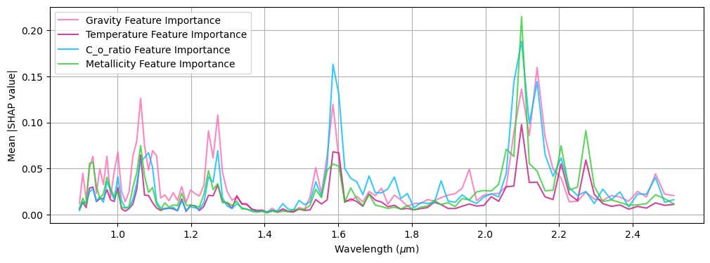

```python
# Visualize
plt.figure(figsize=(12, 4))
colors = ['#FF69B4',  # hot pink
          '#C71585',  # medium violet-red
          '#00BFFF',  # deep sky blue
          '#32CD32']  # lime green
for i,p in enumerate(parameters):
    plt.plot(wl, abs_shap_dict[p],label=f'{p.capitalize()} Feature Importance',
             color=colors[i], alpha=0.8)
plt.xlabel(r'Wavelength ($\mu$m)')
plt.ylabel(r'Mean |SHAP value|')
plt.legend()
plt.grid(True)
```

This combined visualization plots the mean absolute SHAP values across all wavelengths for each of the four atmospheric parameters. Peaks indicate wavelength regions where the model places high importance: 1.1, 1.6, and 2.1 micron.

### **4.2 SHAP Versus Spectra: Temperature**

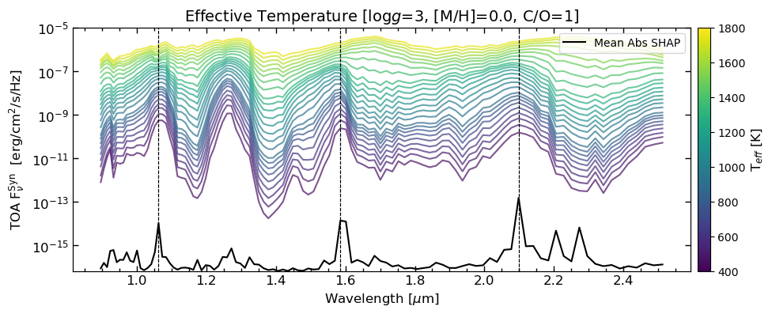

```python
p = 'temperature'
arr = abs_shap_dict[p]
norm_mean_shap = (arr - arr.min()) / (arr.max() - arr.min())


filter_bounds = {'gravity': (3,3),
                 'c_o_ratio' : (1,1),
                 'metallicity' : (0.0,0.0),
                 'temperature': (400, 1800)}

plot_shap_spread(dataset,
                 wl,
                 feature_to_plot=p,
                 filter_bounds=filter_bounds,
                 norm_mean_shap=norm_mean_shap,
                )
```

### **4.3 SHAP Versus Spectra: Gravity**

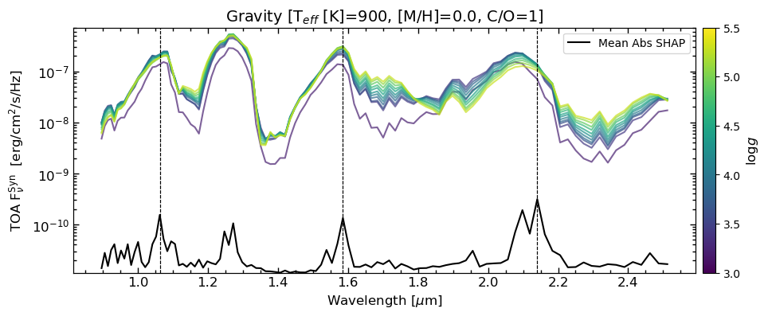

```python
p = 'gravity'
arr = abs_shap_dict[p]
norm_mean_shap = (arr - arr.min()) / (arr.max() - arr.min())

filter_bounds = {'gravity': (3,5.5),
                 'c_o_ratio' : (1,1),
                 'metallicity' : (0.0,0.0),
                 'temperature': (900, 900)}

plot_shap_spread(dataset,
                 wl,
                 feature_to_plot=p,
                 filter_bounds=filter_bounds,
                 norm_mean_shap=norm_mean_shap,
                )
```

### **4.4 SHAP Versus Spectra: C/O Ratio**

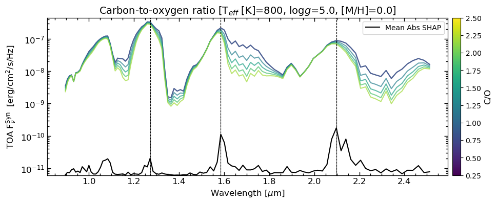

```python
p = 'c_o_ratio'
arr = abs_shap_dict[p]
norm_mean_shap = (arr - arr.min()) / (arr.max() - arr.min())


filter_bounds = {'gravity': (5.,5),
                 'c_o_ratio' : (0.25,2.5),
                 'metallicity' : (0.0,0.0),
                 'temperature': (800, 800)}



plot_shap_spread(dataset,
                 wl,
                 feature_to_plot=p,
                 filter_bounds=filter_bounds,
                 norm_mean_shap=norm_mean_shap,
                )
```